# CaseStudy9

## Earnings reports

The following graphics show the total earnings for each day, week, and month during the observation period. In the graphics, the two companies to pay attention to are LeBelle and Tacontento.

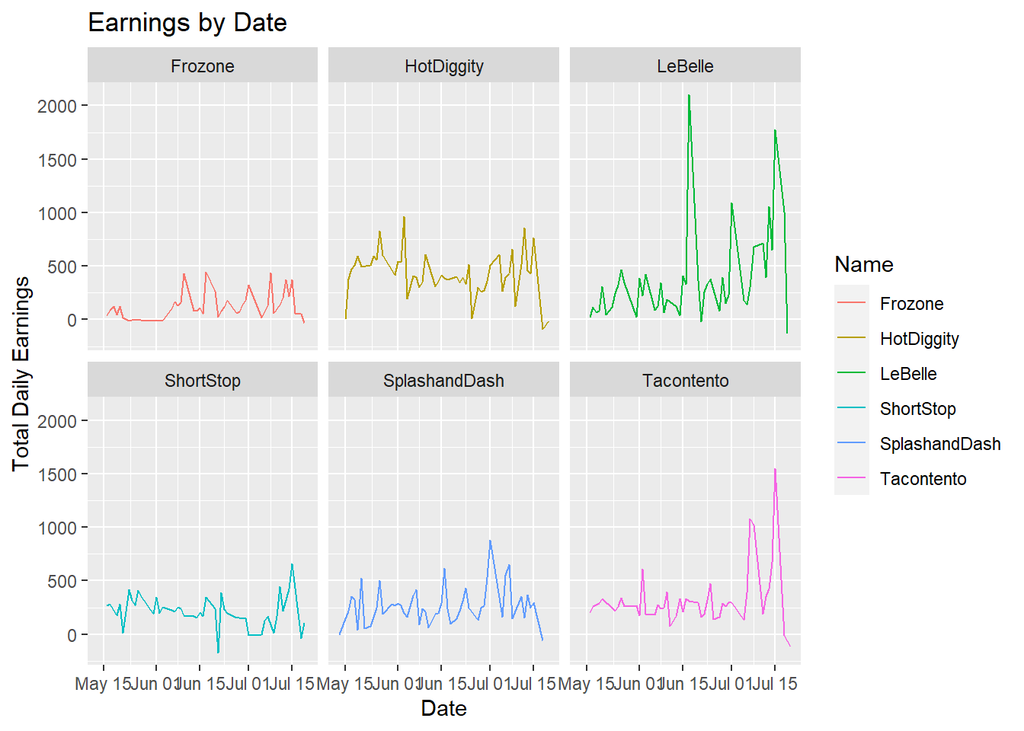

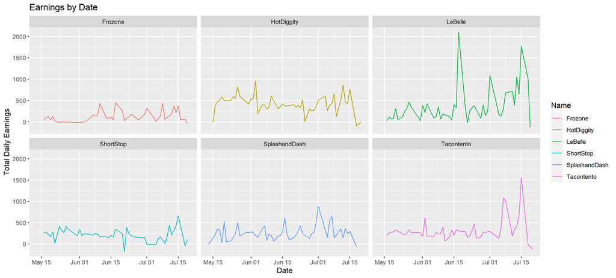

```r
#sales by day
salesMountain %>%
  filter(Name != "Missing") %>%
  mutate(day = date(Hour)) %>%
  group_by(Name, day) %>%
  summarise(earnings = sum(Amount),
            Hour = Hour) %>%
  ggplot(aes(x=day,y=earnings, color = Name))+
  #geom_bar(stat = "identity")+
  geom_line()+
  facet_wrap(. ~ Name)+
  labs(title="Earnings by Date",
       x="Date",
       y="Total Daily Earnings")
```

The daily revenue for each company appears to hold relatively steady for all of the companies except for LeBelle and Taconteno.

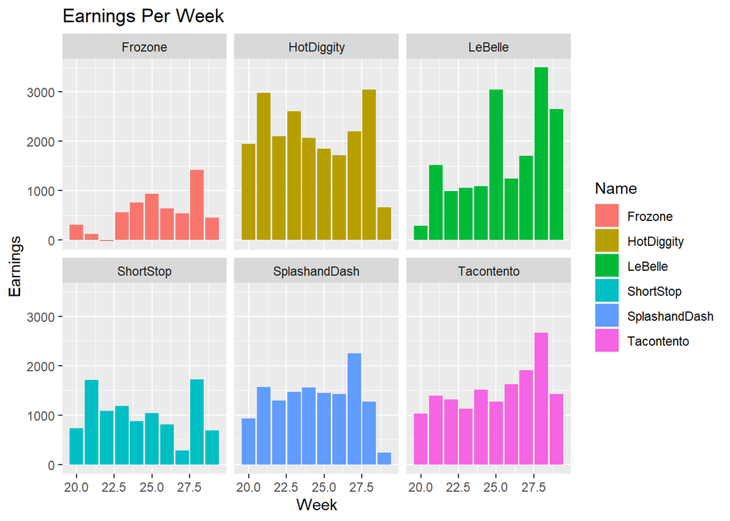

```r
salesMountain %>%
  filter(Name != "Missing") %>%
  group_by(week = week(Time), Name) %>%
  summarise(earnings = sum(Amount)) %>%
  ggplot(aes(x=week, y=earnings, fill = Name))+
  geom_bar(stat="identity")+
  facet_wrap(. ~ Name)+
  labs(title = "Earnings Per Week",
       x="Week",
       y="Earnings")
```

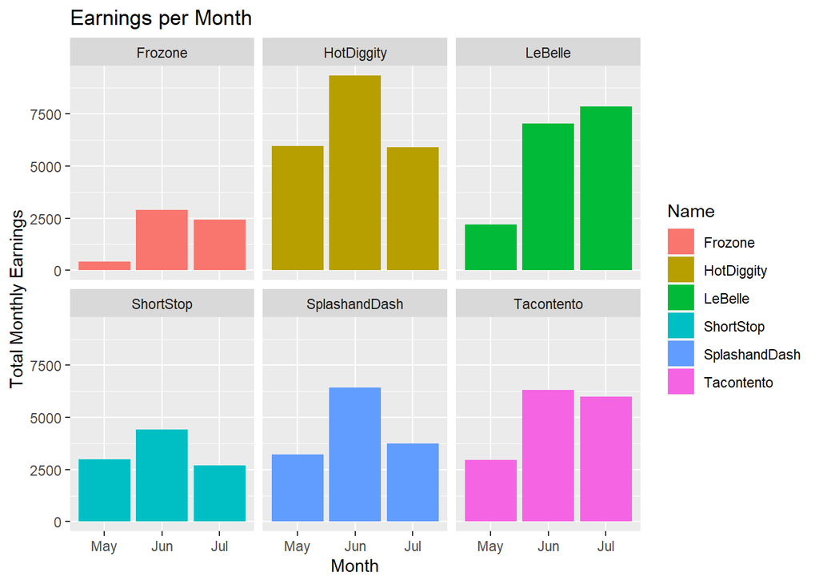

[figure not shown]

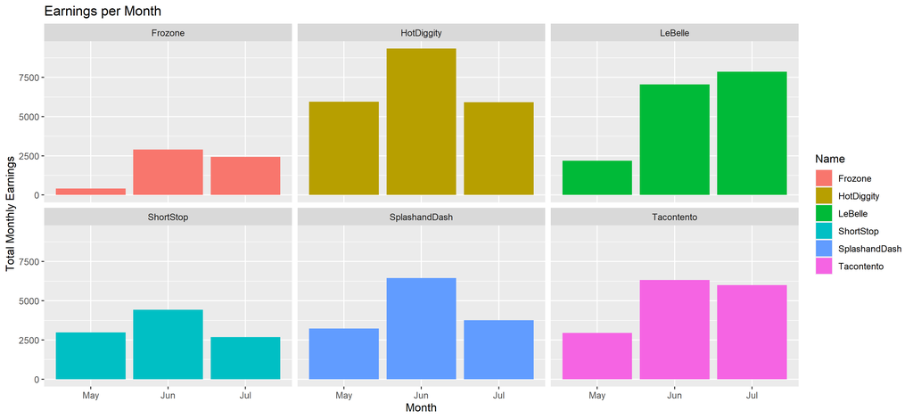

```r
salesMountain %>%
  filter(Name != "Missing") %>%
  mutate(month = month(Hour, label = TRUE)) %>%
  group_by(Name, month) %>%
  summarise(earnings = sum(Amount)) %>%
  ggplot(aes(x=month,y=earnings, fill = Name), color = "black")+
  geom_line()+
  geom_bar(stat = "identity")+
  facet_wrap(. ~ Name)+
  labs(title = "Earnings per Month",
       x= "Month",
       y="Total Monthly Earnings")
```

Every company showed a significant increase in sales during the month of June. This lines up with the start of the summer travel season and some schools letting out. LeBelle and Tacontento show an increase of sales in June, but also show signs of growth with Tacontento’s sales being near the same as the month prior, and LeBelle surpassing its earnings in July.

## Hours of Operation

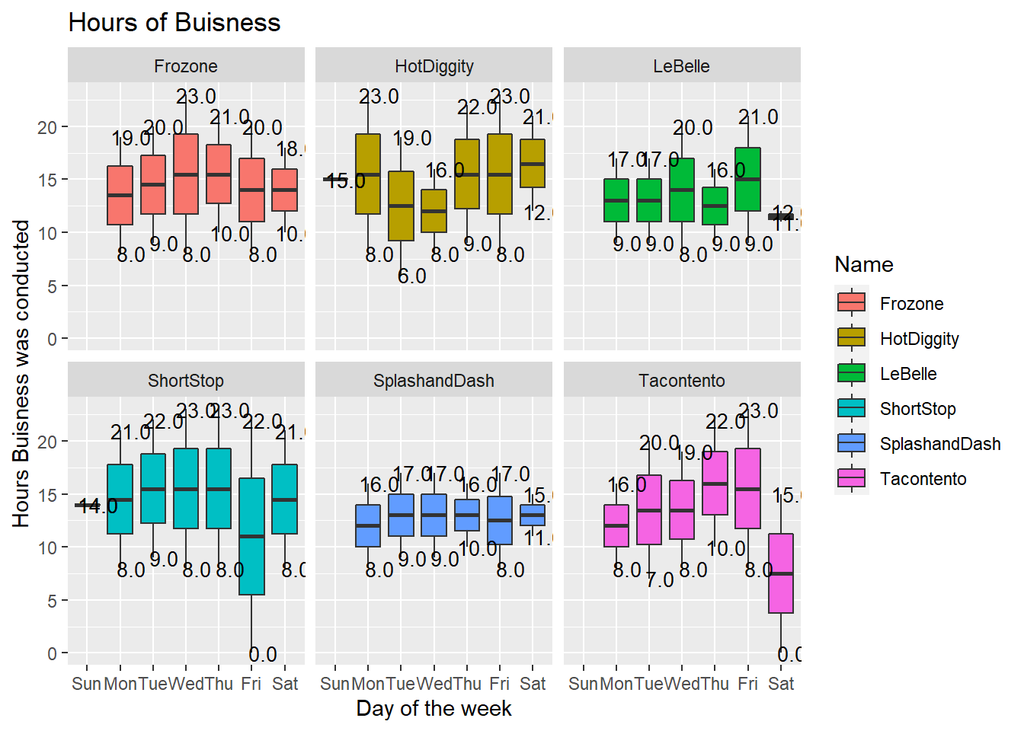

```r
salesMountain %>%
  filter(Name != "Missing") %>%
  mutate(hourOperate = hour(Time)) %>%
  mutate(wday = wday(Time, label = TRUE)) %>%
  group_by(Name, wday) %>%
  summarise(open_close = range(hourOperate),
            close = max(hourOperate)) %>%
  ggplot(aes(x = wday, y= open_close, fill = Name)) +
  geom_boxplot()+
  stat_summary(geom="text", fun = range,
               aes(label=sprintf("%1.1f", ..y..)),
               position=position_nudge(x=0.33), size=3.5) +
  facet_wrap(.~ Name)+
  labs(title = "Hours of Buisness",
       x= "Day of the week",
       y= "Hours Buisness was conducted")
```

```r
salesMountain %>%
  filter(Name != "Missing") %>%
  mutate(hourOperate = hour(Time)) %>%
  mutate(wday = wday(Time, label = TRUE)) %>%
  group_by(Name, wday) %>%
  summarise(open = min(hourOperate),
            close = max(hourOperate)) %>%
  pander()
```

| Name | wday | open | close |
| --- | --- | --- | --- |
| Frozone | Mon | 8 | 19 |
| Frozone | Tue | 9 | 20 |
| Frozone | Wed | 8 | 23 |
| Frozone | Thu | 10 | 21 |
| Frozone | Fri | 8 | 20 |
| Frozone | Sat | 10 | 18 |
| HotDiggity | Sun | 15 | 15 |
| HotDiggity | Mon | 8 | 23 |
| HotDiggity | Tue | 6 | 19 |
| HotDiggity | Wed | 8 | 16 |
| HotDiggity | Thu | 9 | 22 |
| HotDiggity | Fri | 8 | 23 |
| HotDiggity | Sat | 12 | 21 |
| LeBelle | Mon | 9 | 17 |
| LeBelle | Tue | 9 | 17 |
| LeBelle | Wed | 8 | 20 |
| LeBelle | Thu | 9 | 16 |
| LeBelle | Fri | 9 | 21 |
| LeBelle | Sat | 11 | 12 |
| ShortStop | Sun | 14 | 14 |
| ShortStop | Mon | 8 | 21 |
| ShortStop | Tue | 9 | 22 |
| ShortStop | Wed | 8 | 23 |
| ShortStop | Thu | 8 | 23 |
| ShortStop | Fri | 0 | 22 |
| ShortStop | Sat | 8 | 21 |
| SplashandDash | Mon | 8 | 16 |
| SplashandDash | Tue | 9 | 17 |
| SplashandDash | Wed | 9 | 17 |
| SplashandDash | Thu | 10 | 16 |
| SplashandDash | Fri | 8 | 17 |
| SplashandDash | Sat | 11 | 15 |
| Tacontento | Mon | 8 | 16 |
| Tacontento | Tue | 7 | 20 |
| Tacontento | Wed | 8 | 19 |
| Tacontento | Thu | 10 | 22 |
| Tacontento | Fri | 8 | 23 |
| Tacontento | Sat | 0 | 15 |

[figure not shown]

## Daily Transactions

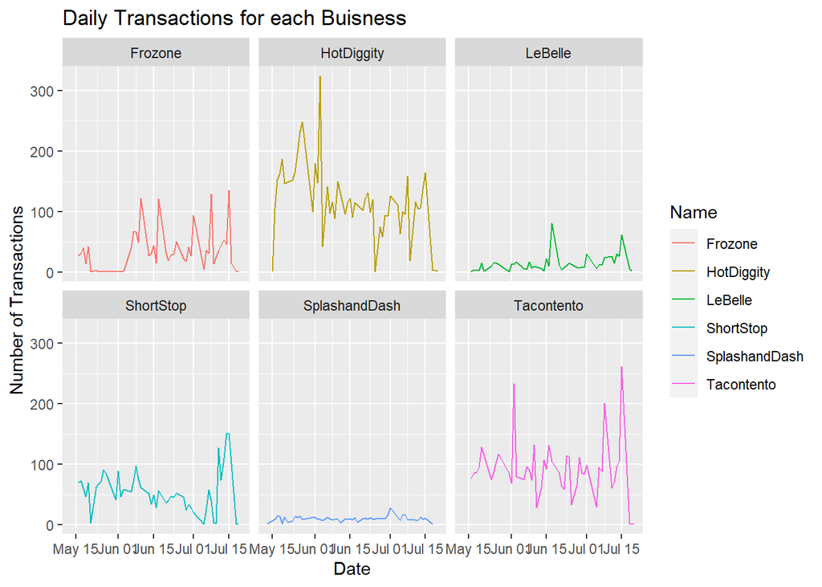

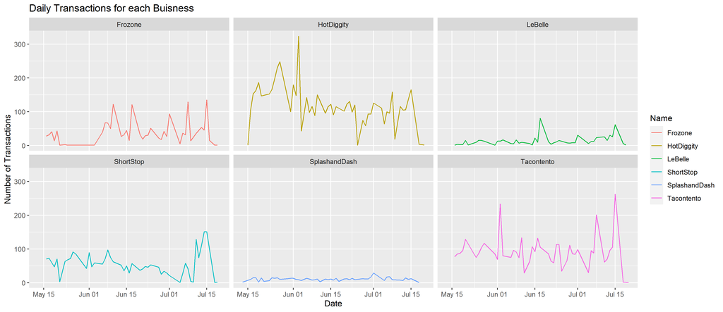

```r
salesMountain %>%
  filter(Name != "Missing") %>%
  mutate(day=date(Hour)) %>%
  count(Name, day) %>%
  ggplot(aes(x=day,y=n, color = Name))+
  geom_line(aes())+
  facet_wrap(.~Name)+
  labs(title = "Daily Transactions for each Buisness",
       x= "Date",
       y= "Number of Transactions")
```

Each business had varying transactions for the observation period. Splash and Dash had a relatively low amount of transactions. Hot Diggity started with a large number of transactions, but overall had a declining number of transactions as the months progressed. LeBelle is slowly growing, as well as Tacontento. Both have a slight upward trend when it comes to their daily transactions.

## Summary

I believe that the best businesses for investment would be LeBelle and Tacontento. LeBelle managed to earn more during the month of July when all others had less than the prior month. They appear to have an increasing number of monthly customers and their total order size also appears to be increasing as well. Tacontento shows potential with the increase of their total number of monthly customers but is not showing an increase of order size.